# Report

## Task 1: Permutation-based Variable Importance for XGBoost model

I trained an `XGBClassifier` model with default parameters on `yeast_me2` dataset. I then used the `dalex` package to perform Permutation-based Variable Importance calculation. Here are the results in terms of loss change as well as ratios.

[figure not shown]

We can clearly see features 0 and 2 as most important, while 4 and 5 are least important.

## Task 2: Different models

I trained a bigger (deeper and more trees), a smaller (shallower and less trees) `XGBClassifier` and a SVM model. Then I calculated PVIs for all of them.

[figure not shown]

The results are quite interesting. The two most important features stay the same: 0 and 2, the SVM model has all of the feature importances quite similar to basic XGBoost model. The bigger and smaller XGBoost model however change the importance of some features (ex. 1). Both of those models have negative importances, which is quite interesting. In the case of the bigger model it may be a result of overfitting, however in the smaller model it is a little bit mysterious.

## Task 3: other feature importance metrics for XGBoost

I have also used the other feature importance metrics which were implemented in `xgboost` package. Those are:

- weight
- total gain
- total cover

[figure not shown]

I have also used the `shap.explainers.Tree` class to derive feature importance based on SHAP values from the TreeSHAP algorithm.

[figure not shown]

Generally speaking, all the methods agree on the unimportance of features 4 and 5.

# Appendix

## Imports and data loading

```python
!pip install -U imbalanced-learn
!pip install xgboost
!pip install dalex
!pip install shap
```

```python
import dalex as dx
import xgboost
import shap

import sklearn

import pandas as pd
import numpy as np

import warnings
warnings.filterwarnings("ignore")
```

```python
from imblearn.datasets import fetch_datasets

imblearn_datasets = fetch_datasets()
```

```python
from collections import Counter

yeast_me2 = imblearn_datasets['yeast_me2']
print("dataset shape: ", yeast_me2.data.shape)
smaller, bigger = list(sorted(Counter(yeast_me2.target).values()))
print(f"{bigger=}, {smaller=}, imbalance ratio={bigger/smaller:.2f}")
```

```
dataset shape:  (1484, 8)
bigger=1433, smaller=51, imbalance ratio=28.10
```

```python
from sklearn.model_selection import train_test_split
from imblearn.over_sampling import SMOTE

X, y = yeast_me2.data, yeast_me2.target
y[y == -1] = 0

X_train, X_test, y_train, y_test = train_test_split(X, y, test_size=0.33, random_state=42)

X_resampled, y_resampled = SMOTE().fit_resample(X_train, y_train)
```

```python
from sklearn.metrics import accuracy_score, confusion_matrix, f1_score, roc_auc_score, recall_score, precision_score

def evaluate_method(method_name, y_test, y_eval, verbose=False):
    results = {
        func.__name__: func(y_test, y_eval) for func in [
            accuracy_score,
            confusion_matrix,
            f1_score,
            roc_auc_score,
            recall_score,
            precision_score
        ]
    }

    if verbose:
        print(method_name, ' results:')
        for func_name, score in results.items():
            print("\t", func_name, ": ", score)

    return results
```

## XGBoost

```python
from xgboost import XGBClassifier

XGBoost_model = XGBClassifier().fit(X_resampled, y_resampled)
y_eval_XGBoost = XGBoost_model.predict(X_test)
results_XGBoost = evaluate_method('XGBoost with SMOTE', y_test, y_eval_XGBoost)
```

## Task 1

```python
def xgboost_classifier(model, data):
    return model.predict_proba(data)[:, 1]

explainer = dx.Explainer(XGBoost_model, X_test, y_test, predict_function=xgboost_classifier)
```

```
Preparation of a new explainer is initiated

  -> data              : numpy.ndarray converted to pandas.DataFrame. Columns are set as string numbers.
  -> data              : 490 rows 8 cols
  -> target variable   : 490 values
  -> model_class       : xgboost.sklearn.XGBClassifier (default)
  -> label             : Not specified, model's class short name will be used. (default)
  -> predict function  : <function xgboost_classifier at 0x7a7d1536d510> will be used
  -> predict function  : Accepts pandas.DataFrame and numpy.ndarray.
  -> predicted values  : min = 3.72e-06, mean = 0.052, max = 1.0
  -> model type        : classification will be used (default)
  -> residual function : difference between y and yhat (default)
  -> residuals         : min = -1.0, mean = -0.0275, max = 0.999
  -> model_info        : package xgboost

A new explainer has been created!
```

```python
explainer.model_performance()
```

|  | recall | precision | f1 | accuracy | auc |
| --- | --- | --- | --- | --- | --- |
| XGBClassifier | 0.583333 | 0.304348 | 0.4 | 0.957143 | 0.917713 |

```python
pvi = explainer.model_parts(random_state=0)
```

```python
pvi.result
```

|  | variable | dropout_loss | label |
| --- | --- | --- | --- |
| 0 | 5 | 0.082287 | XGBClassifier |
| 1 | _full_model_ | 0.082287 | XGBClassifier |
| 2 | 4 | 0.082357 | XGBClassifier |
| 3 | 6 | 0.082758 | XGBClassifier |
| 4 | 7 | 0.094038 | XGBClassifier |
| 5 | 3 | 0.094874 | XGBClassifier |
| 6 | 1 | 0.104986 | XGBClassifier |
| 7 | 2 | 0.200750 | XGBClassifier |
| 8 | 0 | 0.318236 | XGBClassifier |
| 9 | _baseline_ | 0.472873 | XGBClassifier |

```python
pvi.plot(show=False, title="Permutation-based Variable Importance").update_layout(autosize=False, width=600, height=450)
```

[interactive chart not shown]

```python
pvi_ratio = explainer.model_parts(type='ratio', random_state=0)
```

```python
pvi_ratio.plot(show=False, title="Permutation-based Variable Importance (ratio)").update_layout(autosize=False, width=600, height=450)
```

[interactive chart not shown]

## Task 2 - different models

```python
bigger_xgboost = XGBClassifier(
    max_depth=5,
    n_estimators=200
).fit(X_resampled, y_resampled)

bigger_xgboost_explainer = dx.Explainer(bigger_xgboost, X_test, y_test, predict_function=xgboost_classifier)
pvi_ratio = bigger_xgboost_explainer.model_parts(type='ratio', random_state=0)
pvi_ratio.plot(show=False, title="Bigger XGBoost: Permutation-based Variable Importance (ratio)").update_layout(autosize=False, width=600, height=450)
```

```
Preparation of a new explainer is initiated

  -> data              : numpy.ndarray converted to pandas.DataFrame. Columns are set as string numbers.
  -> data              : 490 rows 8 cols
  -> target variable   : 490 values
  -> model_class       : xgboost.sklearn.XGBClassifier (default)
  -> label             : Not specified, model's class short name will be used. (default)
  -> predict function  : <function xgboost_classifier at 0x7a7d1536d510> will be used
  -> predict function  : Accepts pandas.DataFrame and numpy.ndarray.
  -> predicted values  : min = 2.52e-07, mean = 0.048, max = 1.0
  -> model type        : classification will be used (default)
  -> residual function : difference between y and yhat (default)
  -> residuals         : min = -1.0, mean = -0.0235, max = 1.0
  -> model_info        : package xgboost

A new explainer has been created!
```

[interactive chart not shown]

```python
smaller_xgboost = XGBClassifier(
    max_depth=2,
    n_estimators=50
).fit(X_resampled, y_resampled)

smaller_xgboost_explainer = dx.Explainer(smaller_xgboost, X_test, y_test, predict_function=xgboost_classifier)
pvi_ratio = smaller_xgboost_explainer.model_parts(type='ratio', random_state=0)
pvi_ratio.plot(show=False, title="Smaller XGBoost: Permutation-based Variable Importance (ratio)").update_layout(autosize=False, width=600, height=450)
```

```
Preparation of a new explainer is initiated

  -> data              : numpy.ndarray converted to pandas.DataFrame. Columns are set as string numbers.
  -> data              : 490 rows 8 cols
  -> target variable   : 490 values
  -> model_class       : xgboost.sklearn.XGBClassifier (default)
  -> label             : Not specified, model's class short name will be used. (default)
  -> predict function  : <function xgboost_classifier at 0x7a7d1536d510> will be used
  -> predict function  : Accepts pandas.DataFrame and numpy.ndarray.
  -> predicted values  : min = 0.000162, mean = 0.102, max = 0.976
  -> model type        : classification will be used (default)
  -> residual function : difference between y and yhat (default)
  -> residuals         : min = -0.962, mean = -0.0775, max = 0.994
  -> model_info        : package xgboost

A new explainer has been created!
```

[interactive chart not shown]

```python
from sklearn.svm import SVC

svm = SVC(probability=True).fit(X_resampled, y_resampled)

exp_svm = dx.Explainer(svm, X_test, y_test, label="SVM", verbose=False)
pvi_ratio = exp_svm.model_parts(type='ratio', random_state=0)
pvi_ratio.plot(show=False, title="SVM: Permutation-based Variable Importance (ratio)").update_layout(autosize=False, width=600, height=450)
```

[interactive chart not shown]

## Task 3

### XGBoost `feature_importances`

```python
import matplotlib.pyplot as plt
```

```python
types = ['weight', 'total_gain', 'total_cover']
df = pd.DataFrame([pd.Series(XGBoost_model.get_booster().get_score(importance_type=type_)) for type_ in types], index=types).T
```

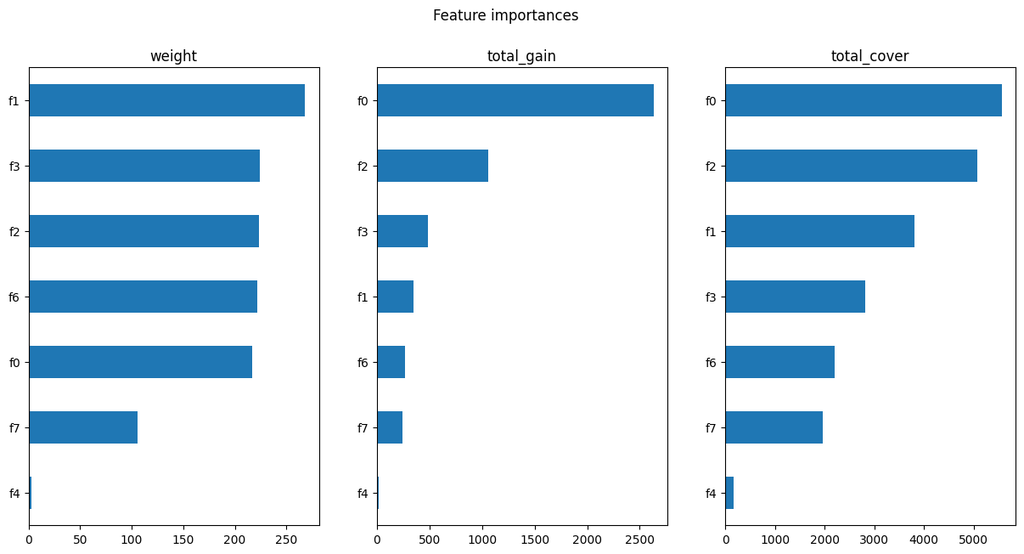

```python
fig, axes = plt.subplots(ncols=3, squeeze=True, figsize=(15, 7))
fig.suptitle("Feature importances")
for type_, ax in zip(types, axes):
    df.sort_values(type_)[type_].plot(kind='barh', ax=ax, title=str(type_))
```

[output not shown]

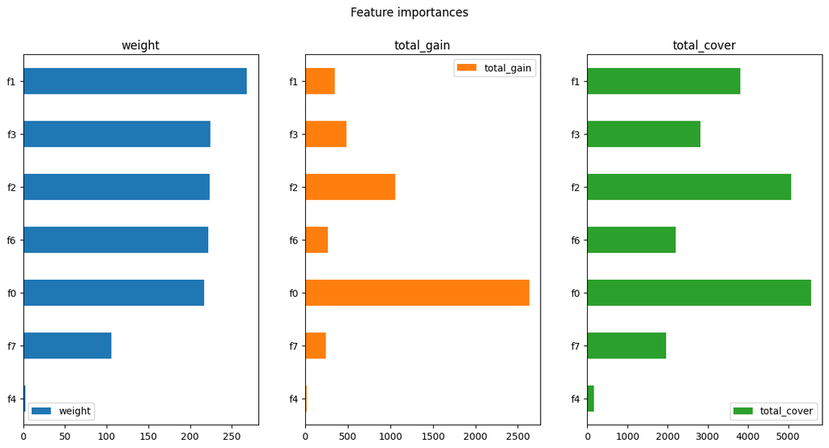

```python
df.sort_values('weight').plot(kind='barh', subplots=True, layout=(1, 3), sharex=False, figsize=(15, 7), title="Feature importances")
```

### `shap` package

```python
shap_explainer = shap.explainers.Tree(XGBoost_model, data=X_test, model_output="probability")
shap_values = shap_explainer(X)
```

[output not shown]

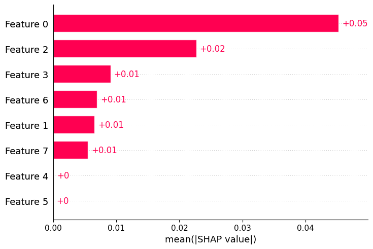

```python
shap.plots.bar(shap_values)
```